# PS-ON Cell Line Image PCA Example

## Setup

Load packages, log into Synapse, etc.

```r
# library(imager)
library(tiff)
```

[output not shown]

## Data collection

Get Synapse IDs for TIFF images of the **MDA-MB-231** breast cancer cell line from the motility study (from a single plate in the “Hyaluronic Acid Fibronectin” condition).

```r
query <- stringr::str_glue("
SELECT * FROM syn7747734
WHERE (
  ( fileFormat = 'tif' ) AND
  ( study = 'Motility' ) AND
  ( diagnosis = 'Breast Cancer' ) AND
  ( cellLine = 'MDA-MB-231' ) AND
  ( experimentalCondition = 'Hyaluronic Acid Fibronectin' )
  AND (name LIKE '%plate_1%001.tif')
)
                          ")
query
```

```
SELECT * FROM syn7747734
WHERE (
  ( fileFormat = 'tif' ) AND
  ( study = 'Motility' ) AND
  ( diagnosis = 'Breast Cancer' ) AND
  ( cellLine = 'MDA-MB-231' ) AND
  ( experimentalCondition = 'Hyaluronic Acid Fibronectin' )
  AND (name LIKE '%plate_1%001.tif')
)
```

```r
pson_motil_img_meta_df <- synTableQuery(
  query, includeRowIdAndRowVersion = FALSE
) %>%
  as.data.frame()
```

Download and load image from the last time point.

```r
img_file <- pson_motil_img_meta_df %>%
  slice(n()) %>%
  pluck("id") %>%
  synGet(downloadLocation = "../data/")
cell_img <- load.image(img_file$path)
cell_img
```

```
Image. Width: 1280 pix Height: 1024 pix Depth: 1 Colour channels: 1
```

## View cell image

Here’s what the image looks like, as downloaded.

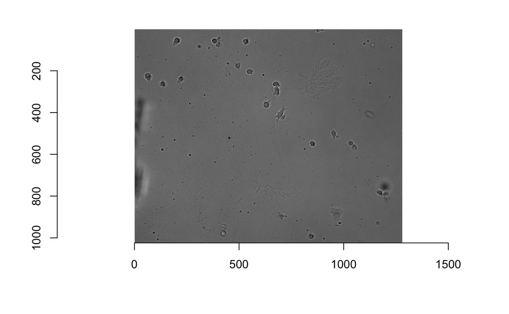

```r
plot(cell_img)
```

If we save the file as a JPEG (with maximum quality), we can get a starting size.

```r
save.image(cell_img, "img.jpeg", quality = 1)
fs::file_info("img.jpeg") %>%
  pluck("size")
```

```
624K
```

## Image compression with PCA

Convert the image to a matrix and compute principal components (PCs) with `prcomp`.

```r
cell_img_mat <- as.matrix(cell_img)
cell_img_pca <- prcomp(cell_img_mat)
```

The number of PCs (not surprisingly) is equal to the dimensions of the original image.

```r
cell_img_pca_tidy <- tidy(cell_img_pca, matrix = "pcs")
nrow(cell_img_pca_tidy)
```

[output not shown]

Let’s check out the percent variance explained by the top 50 PCs.

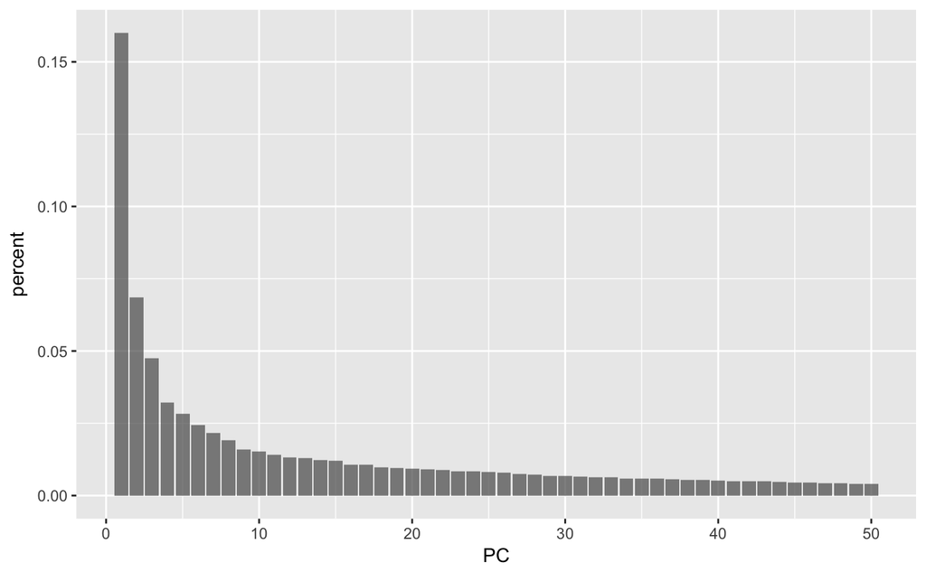

A fair amount of variance in the image data is explained by PC1. I’ll create a function to pick out the top **`num_pcs`** to create a compressed version of the image. Plotting the reconstructed image from PC1 only:

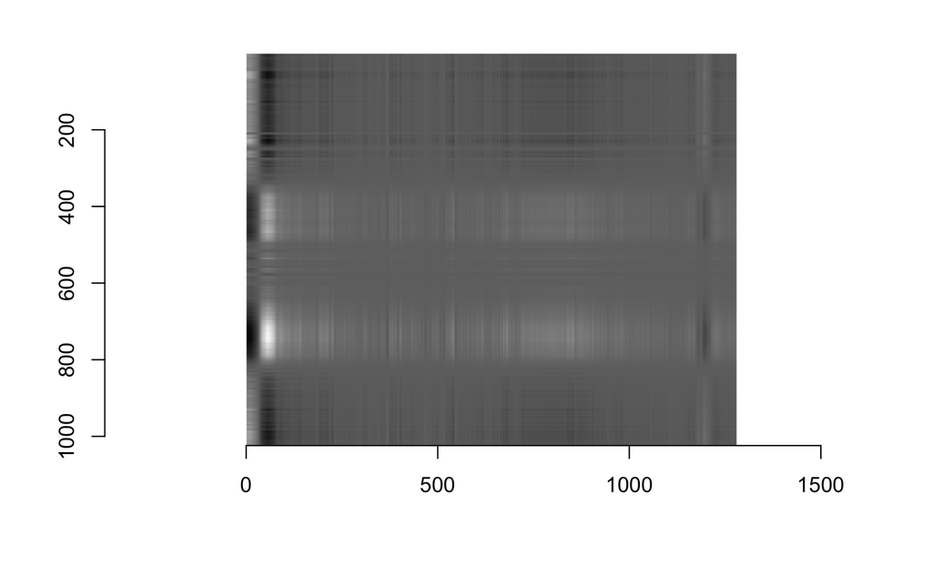

```r
compress_img <- function(img_pca, num_pcs) {
  img_pca$x[, 1:num_pcs] %*% t(img_pca$rotation[, 1:num_pcs]) %>%
    t() %>%
    as.cimg()
}
compress_img(cell_img_pca, num_pcs = 1) %>%
  plot()
```

So, a certainly a hint of the original… What about using the top 10 PCs?

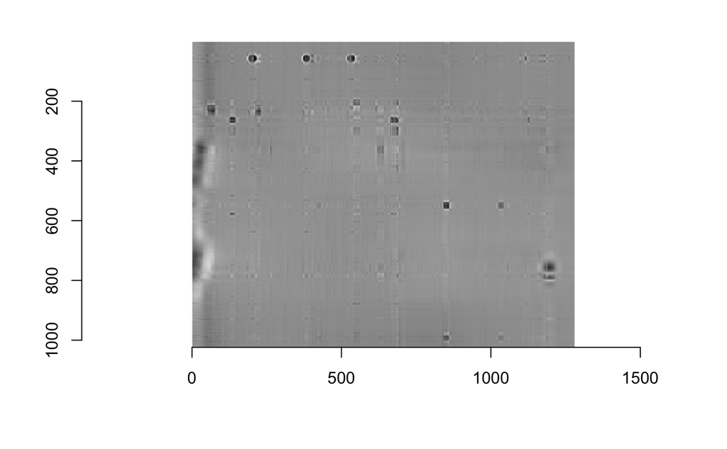

```r
compress_img(cell_img_pca, num_pcs = 10) %>%
  plot()
```

Approaching the compression a bit more systematically, I can figure out how many PCs would be needed to capture 75% of the variation (~information) in the image data.

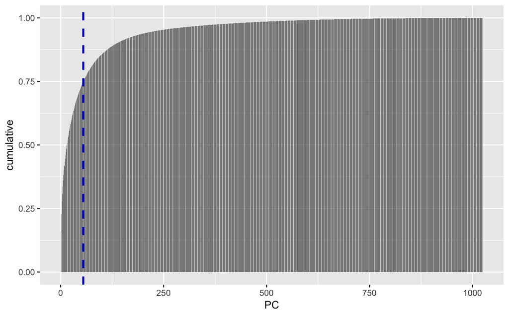

```r
cell_img_pca_tidy %>%
  ggplot(aes(x = PC, y = cumulative)) +
  geom_col(alpha = 0.7) +
  geom_vline(aes(xintercept = max(PC[cumulative <= 0.75])),
             linetype = 2, size = 1, colour = "blue3")
```

```r
pcs_75 <- cell_img_pca_tidy %>%
    filter(cumulative <= .75) %>%
    top_n(1, PC) %>%
    pluck("PC")
pcs_75
```

```
[1] 55
```

That’s only **55** PCs (out of 1024) to reconstruct a fairly accurate version of the image!

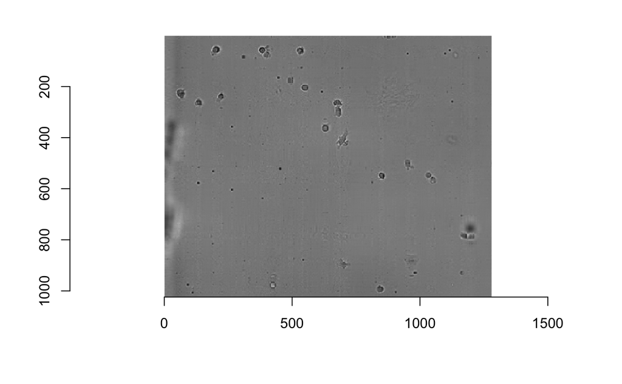

```r
compress_img(cell_img_pca, num_pcs = pcs_75) %>%
  plot()
```

I can now save the compressed image as a JPEG to see the resulting file size.

```r
cell_img_compressed <- compress_img(cell_img_pca, num_pcs = pcs_75)
save.image(cell_img_compressed, "img_compressed.jpeg", quality = 1)
fs::file_info("img_compressed.jpeg") %>%
  pluck("size")
```

```
393K
```

That’s about 60% of the original file size. Success!